# STA 141A Final Project: Predicting Success Rates in Mice during a Visual Decision

Shreyans Porwal

2025-03-17

# Abstract

# Section 1: Introduction

# 1.1 Sessions Table and Definitions

| mouse_name | date_exp | n_brain_area | n_neurons | n_trials | success_rate |
| --- | --- | --- | --- | --- | --- |
| Cori | 2016-12-14 | 8 | 734 | 114 | 0.61 |
| Cori | 2016-12-17 | 5 | 1070 | 251 | 0.63 |
| Cori | 2016-12-18 | 11 | 619 | 228 | 0.66 |
| Forssmann | 2017-11-01 | 11 | 1769 | 249 | 0.67 |
| Forssmann | 2017-11-02 | 10 | 1077 | 254 | 0.66 |
| Forssmann | 2017-11-04 | 5 | 1169 | 290 | 0.74 |
| Forssmann | 2017-11-05 | 8 | 584 | 252 | 0.67 |
| Hench | 2017-06-15 | 15 | 1157 | 250 | 0.64 |
| Hench | 2017-06-16 | 12 | 788 | 372 | 0.69 |
| Hench | 2017-06-17 | 13 | 1172 | 447 | 0.62 |
| Hench | 2017-06-18 | 6 | 857 | 342 | 0.80 |
| Lederberg | 2017-12-05 | 12 | 698 | 340 | 0.74 |
| Lederberg | 2017-12-06 | 15 | 983 | 300 | 0.80 |
| Lederberg | 2017-12-07 | 10 | 756 | 268 | 0.69 |
| Lederberg | 2017-12-08 | 8 | 743 | 404 | 0.76 |
| Lederberg | 2017-12-09 | 6 | 474 | 280 | 0.72 |
| Lederberg | 2017-12-10 | 6 | 565 | 224 | 0.83 |
| Lederberg | 2017-12-11 | 10 | 1090 | 216 | 0.81 |

Instead of creating a table to summarize the key characteristics of the four mice, I chose to create a table for all 18 sessions involving the 4 mice.

# My Takeaway

The most important takeaway from this table is heterogeneity. The number of neurons, brain areas, and trials vary a lot throughout the sessions. If we combine all of this data without considering these differences, it would lead to biased or misleading results.

# Section 2: Data Integration

Transforms the data from the .rds files into a single data frame to prepare for EDA and modeling. This data frame will have one row per brain area per trial.

# Section 4: Exploratory Data Analysis

# 4.1 Stimuli and Feedback Distributions

[figure not shown]

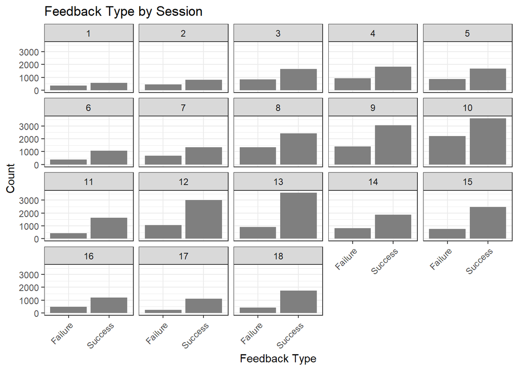

A and B: These histograms show that the contrast_left and contrast_right level of 0 is the most frequent. The contrast levels of 0.25, 0.5, and 1 all appear to be at a roughly similar frequency. These results support the idea that the contrast levels are relatively balanced because the levels with some stimulus should be at a roughly similar frequency. The contrast level of 0 should have most of the frequency because when contrast_left=0, contrast_right might be nonzero.

D: Overall, the success bars were higher than the failure bars, meaning the mice were mostly successful. However, in some sessions, the success bar was slightly higher than failure (session 1), and in other sessions the success bar was more than three times higher than the failure bar (session 13). This could suggest that outside factors may have affected the feedback.

E: The scatter plot shows failure at the top right of the map, meaning mice failed the task when a high contrast level was given on the left and right side. This makes sense because it would be hard for the mice to determine what side is correct. The plot is also relatively symmetrical, this tells us that the experiment set up is balanced.

# 4.2 Neuronal Activity

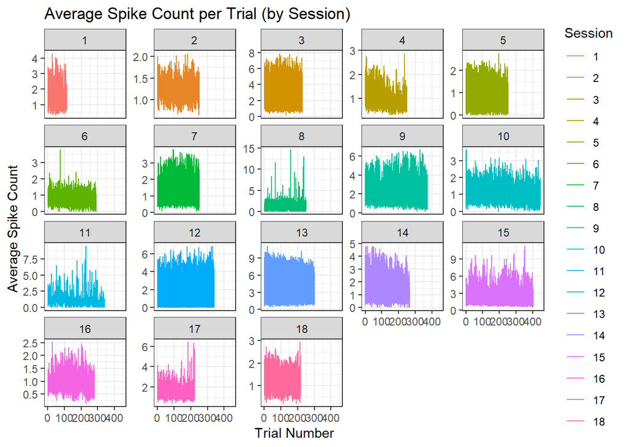

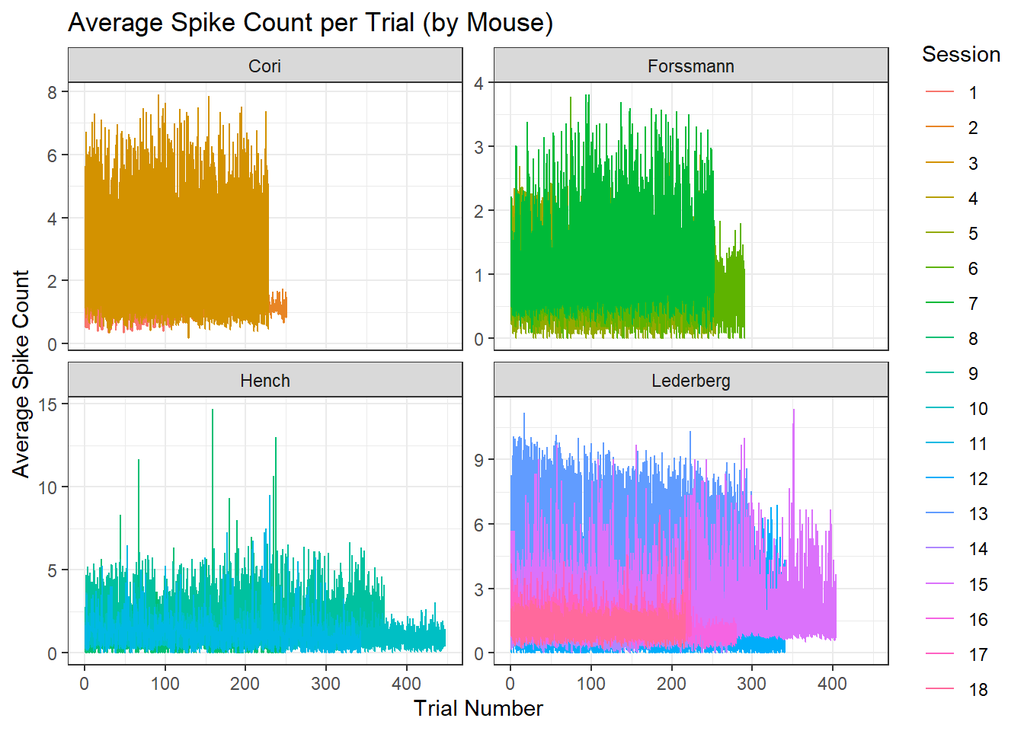

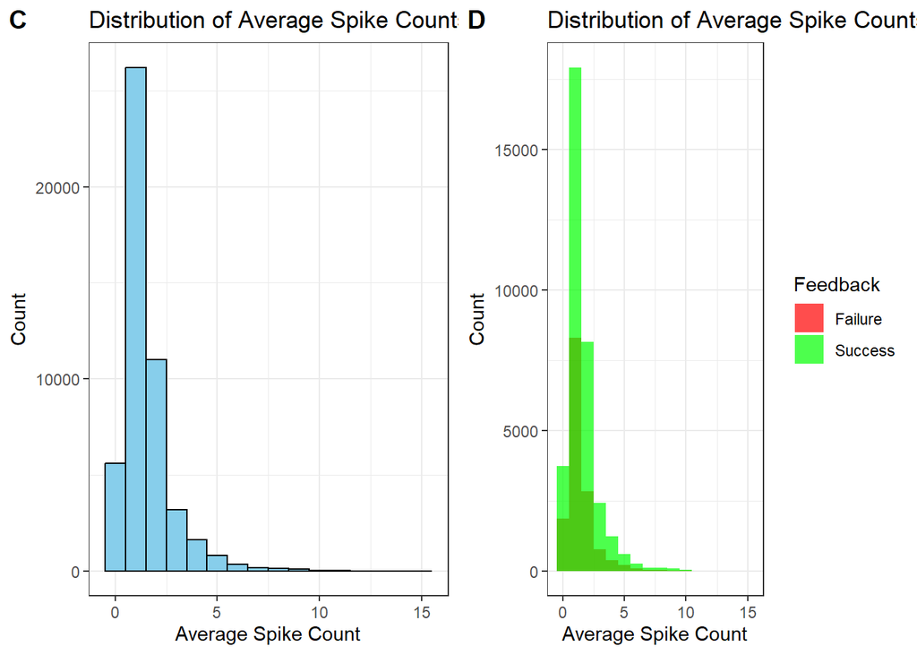

A: In the Average Spike Count Per Trial by session plots, we can see that some sessions (11,13,15) have higher average spike counts than the other sessions. This further supports the heterogeneity I mentioned in 1.1, which also supports the data integration idea of averaging.

C and D: The first bar plot tells us that the average spike count for most trials was between 1 and 2, with a heavy right skew. This tells us that we might want to transform the average spike count by region variable using log(). This might help make the model more symmetrical. The second bar plot has exactly the same shape, but it’s clear that most trials were a success rather than a failure despite what the average spike count was.

# 4.3 Brain Area Analysis

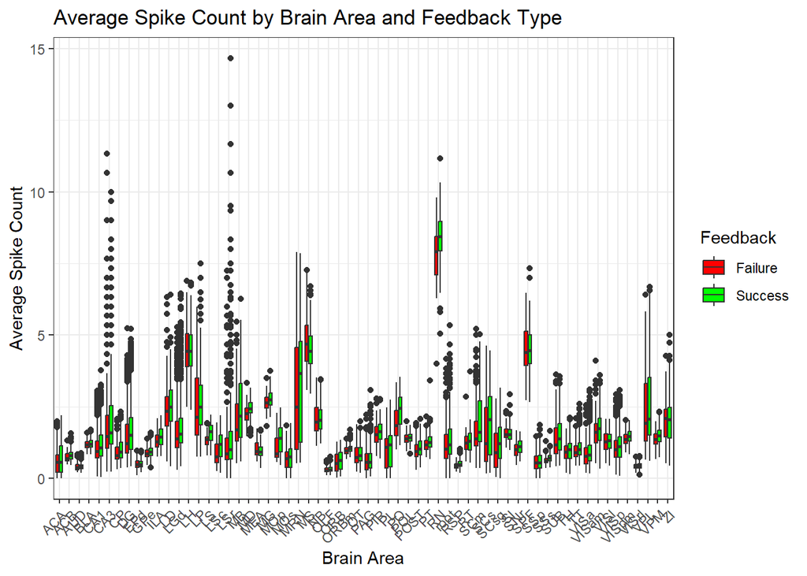

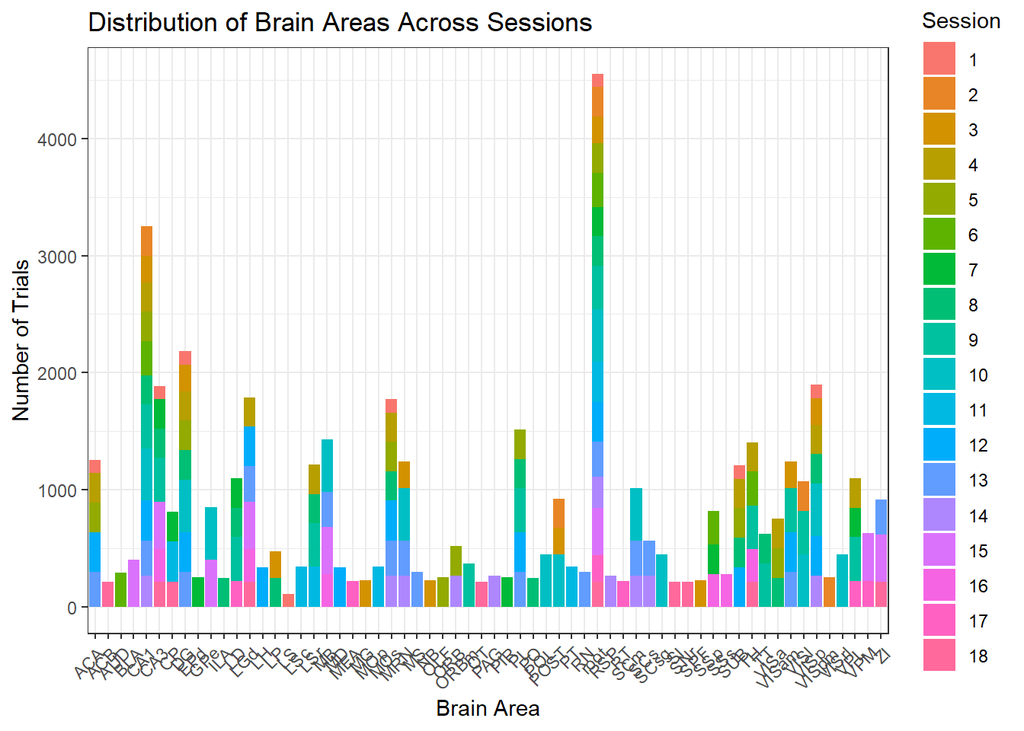

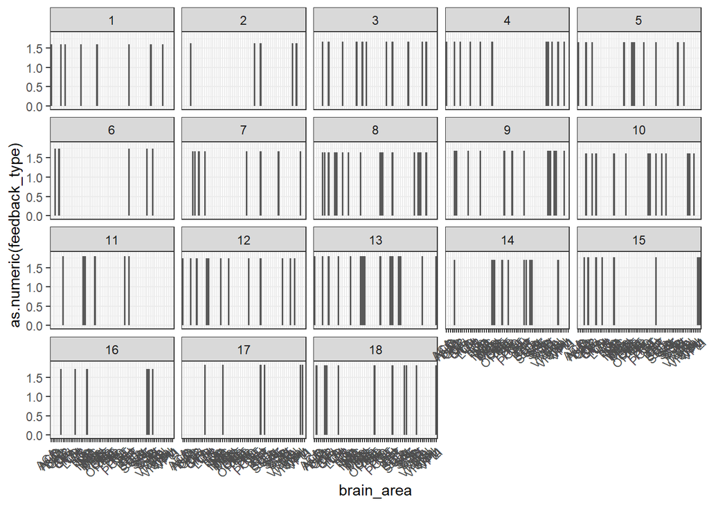

Distribution of Brain Areas Across Sessions: This graph represents the total number of times a trial was recorded in a brain area. Some brain areas like RN were included in most trials. This tells us that we can’t just combine all of the data without considering which brain areas were recorded how many times. If I use brain areas in the model, some areas could greatly influence the model.

# Section 3: PCA vs ICA (Assumptions Testing)

```
## # A tibble: 7 × 4
##   Variable        Pearson Spearman Difference
##   <chr>             <dbl>    <dbl>      <dbl>
## 1 brain_areaLH     0.205    0.133     -0.0720
## 2 brain_areaMRN    0.226    0.141     -0.0856
## 3 brain_areaMS     0.198    0.126     -0.0722
## 4 brain_areaRN     0.443    0.135     -0.308
## 5 brain_areaSPF    0.169    0.109     -0.0594
## 6 brain_areaVISam  0.0250   0.0890     0.0640
## 7 brain_areaZI     0.0564   0.107      0.0506
```

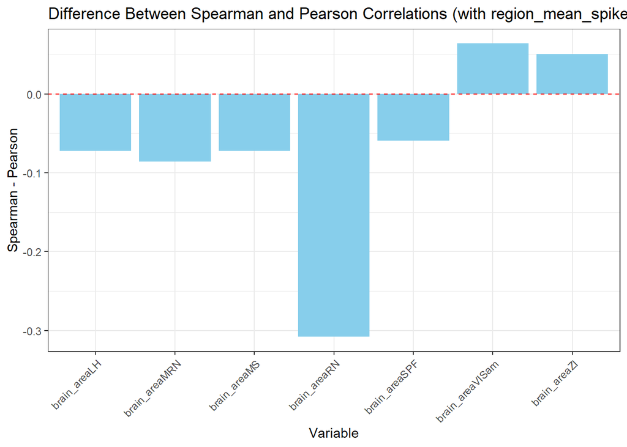

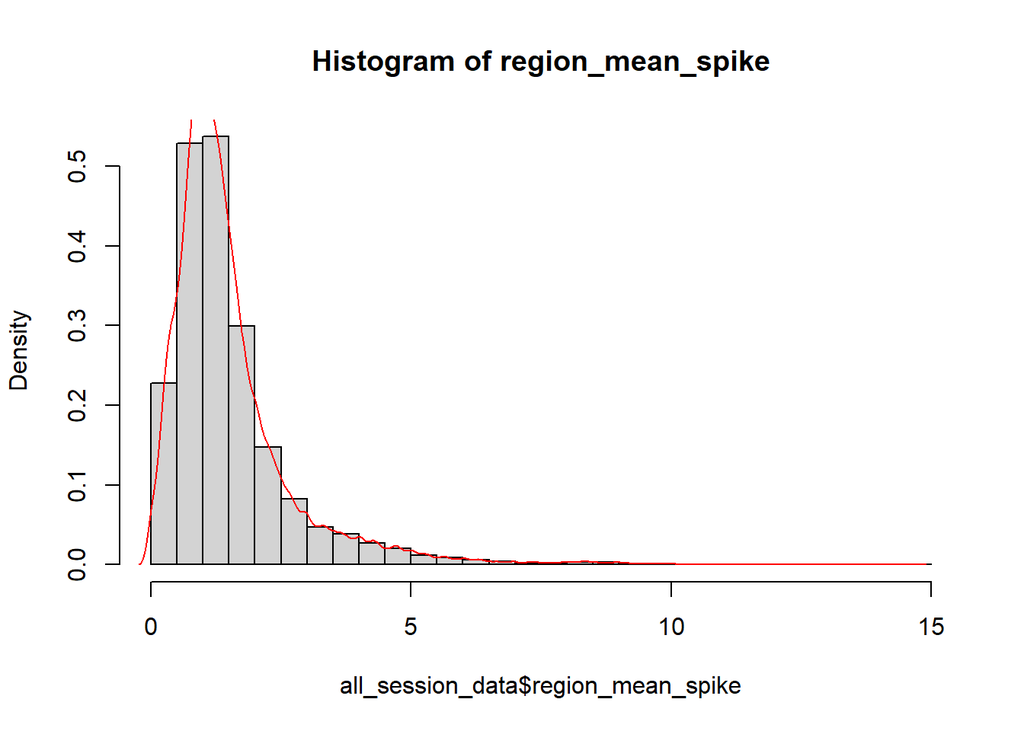

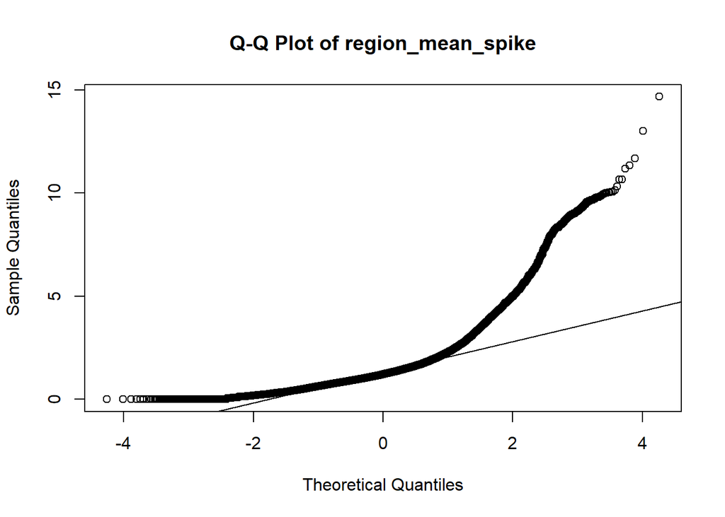

```
##
##  Shapiro-Wilk normality test
##
## data:  spike_data_sample
## W = 0.78594, p-value < 2.2e-16
##
##
##  Anderson-Darling normality test
##
## data:  spike_data_sample
## A = 259.59, p-value < 2.2e-16
```

```
## [1] "Mouse: Cori Session: 1"
##  lag Autocorrelation D-W Statistic p-value
##    1       0.0973108      1.804472   0.004
##  Alternative hypothesis: rho != 0
## [1] "Mouse: Cori Session: 2"
##  lag Autocorrelation D-W Statistic p-value
##    1       0.1886282      1.620809       0
##  Alternative hypothesis: rho != 0
## [1] "Mouse: Cori Session: 3"
##  lag Autocorrelation D-W Statistic p-value
##    1     0.001248029      1.997154   0.992
##  Alternative hypothesis: rho != 0
## [1] "Mouse: Cori Session: 4  has not enough data"
## [1] "Mouse: Cori Session: 5  has not enough data"
## [1] "Mouse: Cori Session: 6  has not enough data"
```

[output cut: 111 more lines]